# Managing Long-Running Tasks — Interview Notes

## Index

1. Problem
2. Core Idea: Async Processing
3. High-Level Architecture
4. Job Lifecycle
5. Implementation Flow
6. Queue Technologies
7. Worker Options
8. Benefits
9. Tradeoffs
10. When to Use
11. When NOT to Use
12. Common Interview Examples
13. Common Deep Dives
14. Deep Dive 1: Handling Worker Failures
15. Deep Dive 2: Handling Repeated Failures / DLQ
16. Deep Dive 3: Preventing Duplicate Work
17. Deep Dive 4: Queue Backpressure
18. Deep Dive 5: Mixed Workloads
19. Deep Dive 6: Job Dependencies
20. Decision Tree
21. Golden Interview Answer

## 1. Problem

Normal APIs are fast.

```
User Request
    ↓
Database Query
    ↓
Response in < 100 ms
```

This works for simple operations like:

- View profile
- Fetch order details
- Update user settings
- Simple CRUD APIs

But some operations take a long time.

Examples:

```
Generate PDF Report
Video Transcoding
Image Processing
Large CSV Import
Bulk Email Campaign
ML Inference
Data Export
```

These can take seconds, minutes, or hours.

### Why synchronous processing fails

```
User waits 45 seconds
    ↓
Browser timeout / Load balancer timeout
    ↓
Bad user experience
    ↓
User retries
    ↓
Duplicate work
```

### Main problems

| Problem | Explanation |
| --- | --- |
| Timeout | Web servers/load balancers often timeout around 30–60 seconds |
| Poor UX | User sees loading for a long time |
| Duplicate work | User may click multiple times |
| Resource overload | Web servers get busy doing heavy work |
| Poor scalability | Heavy jobs and normal API traffic compete |

Back to Index

## 2. Core Idea: Async Processing

The solution is to split the request into two phases.

### Phase 1: Accept Request Quickly

```
Client
  ↓
API Server
  ↓
Validate Request
  ↓
Create Job
  ↓
Push Job ID to Queue
  ↓
Return Job ID immediately
```

Example response:

```
{
  "job_id": "job_123",
  "status": "pending",
  "message": "Report generation started"
}
```

### Phase 2: Process in Background

```
Worker
  ↓
Poll Queue
  ↓
Pick Job
  ↓
Process Heavy Task
  ↓
Store Result
  ↓
Update Job Status
```

### Simple definition

> Long-running task pattern decouples **request acceptance** from **request processing**.

The API does not do the heavy work. It only accepts the job and returns quickly.

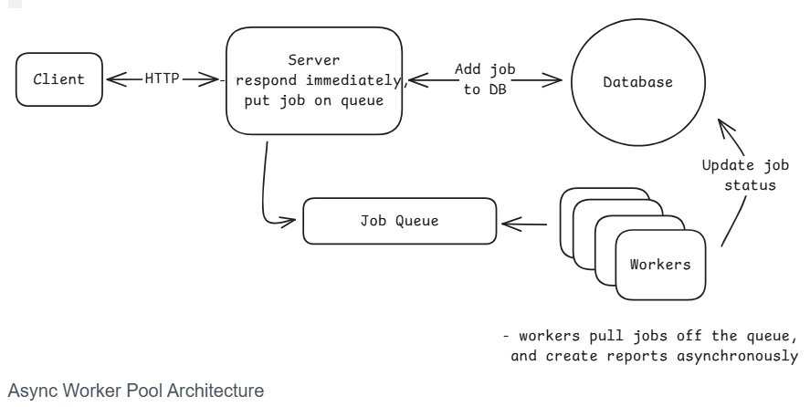

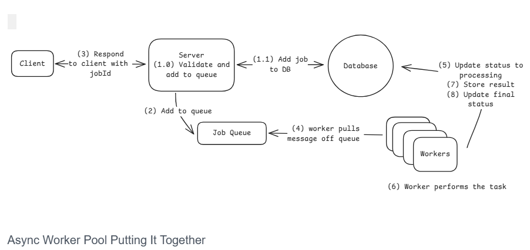

Back to Index

## 3. High-Level Architecture

```
Client
   ↓
API Server
   ↓
Job Database
   ↓
Message Queue
   ↓
Worker Pool
   ↓
Storage / Database / S3
   ↓
Notification System
```

### Main components

| Component | Responsibility |
| --- | --- |
| API Server | Validate request, create job, return job ID |
| Job Database | Store job status and metadata |
| Message Queue | Buffer jobs between API and workers |
| Worker Pool | Execute heavy work |
| Storage | Store output files or results |
| Notification | Inform user when job is done |

### Why queue is important

The queue:

- Decouples API and workers
- Buffers spikes
- Stores pending jobs
- Allows retry
- Helps scaling workers independently

Back to Index

## 4. Job Lifecycle

A long-running job usually moves through states.

```
Pending
   ↓
Processing
   ↓
Completed
```

Failure path:

```
Pending
   ↓
Processing
   ↓
Failed
```

Retry path:

```
Processing
   ↓
Failed
   ↓
Retrying
   ↓
Processing
```

### Common job states

| State | Meaning |
| --- | --- |
| Pending | Job accepted but not started |
| Processing | Worker is executing the job |
| Completed | Job finished successfully |
| Failed | Job failed permanently |
| Retrying | Job failed but will be retried |
| Cancelled | User/system cancelled the job |

### Status API

Clients usually poll:

```
GET /jobs/{job_id}
```

Example response:

```
{
  "job_id": "job_123",
  "status": "completed",
  "result_url": "s3://reports/report_123.pdf"
}
```

Back to Index

## 5. Implementation Flow

### Step-by-step flow

```
1. User submits request
2. API validates request
3. API creates job row in DB with status = pending
4. API pushes job_id to queue
5. API returns job_id to user
6. Worker pulls job_id from queue
7. Worker fetches job details from DB
8. Worker updates status = processing
9. Worker performs actual work
10. Worker stores result in DB/S3
11. Worker updates status = completed or failed
12. User is notified or checks job status
```

### Important design choice

Queue message should usually contain only the `job_id`, not the full payload.

```
{
  "job_id": "job_123"
}
```

Why?

- Keeps queue message small
- Large payload stays in DB/S3
- Easier retries
- Easier debugging
- Avoids queue size limits

Back to Index

## 6. Queue Technologies

| Technology | Best For | Notes |
| --- | --- | --- |
| Redis + BullMQ | Simple job queues, startups | Easy, fast, but memory-first |
| AWS SQS | Managed queue | Durable, scalable, low ops |
| RabbitMQ | Complex routing | Good enterprise queue |
| Kafka | High scale, replay, streaming | Great when replay and ordering matter |

### Redis + BullMQ

Use when:

- You want simple setup
- Jobs are not extremely critical
- You need retries, delayed jobs, priority queues

### AWS SQS

Use when:

- You are on AWS
- You want managed infrastructure
- You need durable queueing

### RabbitMQ

Use when:

- You need routing patterns
- You need traditional message broker features

### Kafka

Use when:

- You already use Kafka
- You need high throughput
- You need replay
- You need event streaming

### Interview default

> I will use a durable queue like Kafka, SQS, or RabbitMQ depending on scale and cloud environment.

Back to Index

## 7. Worker Options

Workers execute the actual heavy task.

### Option 1: Normal Servers

```
Worker Process
    ↓
Poll Queue
    ↓
Process Job
```

#### Pros

- Simple
- Easy debugging
- Good for long-running jobs
- Full control

#### Cons

- Pay for idle capacity
- Need to manage servers

### Option 2: Serverless Workers

Examples:

```
AWS Lambda
Google Cloud Functions
Azure Functions
```

#### Pros

- Auto scaling
- No server management
- Pay per execution

#### Cons

- Execution time limits
- Cold starts
- Limited local storage
- Not ideal for very long jobs

### Option 3: Container Workers

Examples:

```
Kubernetes
ECS
Docker
```

#### Pros

- Flexible
- Good for different hardware needs
- Auto scaling possible
- Good for long-running jobs

#### Cons

- More operational complexity

### Interview recommendation

Use Kubernetes/ECS workers for serious production long-running tasks. Use Lambda for short, spiky jobs.

Back to Index

## 8. Benefits

### 1. Fast User Response

```
API returns in milliseconds
instead of waiting minutes
```

### 2. Independent Scaling

```
Web Servers → Handle user traffic
Workers     → Handle heavy processing
```

### 3. Fault Isolation

```
Worker Crash
      ↓
API Still Works
```

### 4. Better Resource Utilization

```
API servers      → small instances
Video workers    → GPU machines
PDF workers      → CPU optimized
Large data jobs  → memory optimized
```

### 5. Better User Experience

User gets:

- Immediate confirmation
- Job ID
- Progress status
- Notification after completion

Back to Index

## 9. Tradeoffs

This pattern improves scalability but adds complexity.

| Gain | Cost |
| --- | --- |
| Fast API response | More infrastructure |
| Independent scaling | Queue and worker monitoring |
| Fault isolation | Retry handling |
| Better resource usage | Job status tracking |
| Better UX | Eventual consistency |

### Main disadvantages

- More moving parts
- Need job database
- Need retry logic
- Need monitoring
- Need DLQ
- User result is not immediately available
- System becomes eventually consistent

### Important interview statement

> Async processing improves reliability and scalability, but it introduces eventual consistency and operational complexity.

Back to Index

## 10. When to Use

Use this pattern when the operation takes more than a few seconds.

### Good use cases

| Use Case | Why Async |
| --- | --- |
| Video transcoding | Takes minutes/hours |
| PDF generation | Heavy computation |
| Image processing | CPU/GPU intensive |
| CSV import | Large data processing |
| Bulk emails | High fan-out |
| Data export | Expensive queries |
| ML inference batch | Expensive compute |
| File scanning | External/slow process |
| Feed fanout | Many downstream writes |

### Quick rule

```
Task > few seconds?
    ↓
Use Queue + Workers
```

Back to Index

## 11. When NOT to Use

Do not use this pattern for simple, fast operations.

### Avoid for

| Operation | Reason |
| --- | --- |
| Login | Needs immediate result |
| Simple CRUD | Too much overhead |
| Get profile | Fast DB read |
| Update setting | Simple write |
| Payment authorization | Often needs sync confirmation |
| Small API calls | Queue overhead unnecessary |

### Simple rule

```
Task < 1 second
    ↓
Synchronous API is fine
```

### Warning

Do not overcomplicate simple request-response APIs.

Back to Index

## 12. Common Interview Examples

| System | Long-Running Tasks |
| --- | --- |
| YouTube | Video transcoding, thumbnails, captions |
| Instagram | Image resizing, filters, feed fanout |
| Dropbox | Virus scan, file preview, indexing |
| ChatGPT | Long AI generation, tool execution |
| Uber | Ride matching, driver selection |
| Stripe | Fraud detection, webhook delivery |
| Data Platform | ETL pipelines, imports, exports |
| LinkedIn | Feed fanout, notification delivery |
| LeetCode | Code execution and judge processing |

### Example: YouTube

```
Upload Video
    ↓
Return Upload ID
    ↓
Async Workers:
    - Transcode 1080p
    - Transcode 720p
    - Generate thumbnail
    - Extract captions
    - Content moderation
```

### Example: Instagram

```
Upload Photo
    ↓
Return Success
    ↓
Async Workers:
    - Resize image
    - Generate thumbnails
    - Apply filters
    - Run moderation
    - Fanout post to feeds
```

Back to Index

## 13. Common Deep Dives

Interviewers often ask follow-up questions around failure and scale.

### Main deep dives

1. Worker crashes while processing
2. Job keeps failing repeatedly
3. Duplicate jobs are created
4. Queue grows too large
5. Short jobs stuck behind long jobs
6. Jobs depend on other jobs

These are important because they test whether you understand production failure modes.

Back to Index

## 14. Deep Dive 1: Handling Worker Failures

### Problem

A worker may crash while processing a job.

```
Worker picks job
    ↓
Worker crashes
    ↓
Job incomplete
```

### Solution

Use heartbeat / visibility timeout / session timeout.

### How it works

```
Worker starts job
    ↓
Worker sends heartbeat
    ↓
Queue knows worker is alive
```

If heartbeat stops:

```
Queue assumes worker died
    ↓
Job becomes available again
    ↓
Another worker retries it
```

### Queue-specific examples

| Queue | Mechanism |
| --- | --- |
| SQS | Visibility timeout |
| RabbitMQ | Heartbeat / acknowledgements |
| Kafka | Consumer session timeout |
| Redis/BullMQ | Lock duration + stalled job detection |

### Key interview point

Choose heartbeat timeout carefully.

| Timeout Too Short | Timeout Too Long |
| --- | --- |
| False failures | Slow recovery |
| Duplicate processing | User waits longer |
| Problems during GC pause | Job stuck longer |

Good starting point: `10–30 seconds`, depending on business tolerance.

Back to Index

## 15. Deep Dive 2: Handling Repeated Failures / DLQ

### Problem

Some jobs fail again and again.

Examples:

```
Bad input
Code bug
External API always failing
Poison message
```

Without protection:

```
Job fails
   ↓
Retry
   ↓
Fails again
   ↓
Retry forever
```

This wastes worker capacity.

### Solution: Dead Letter Queue

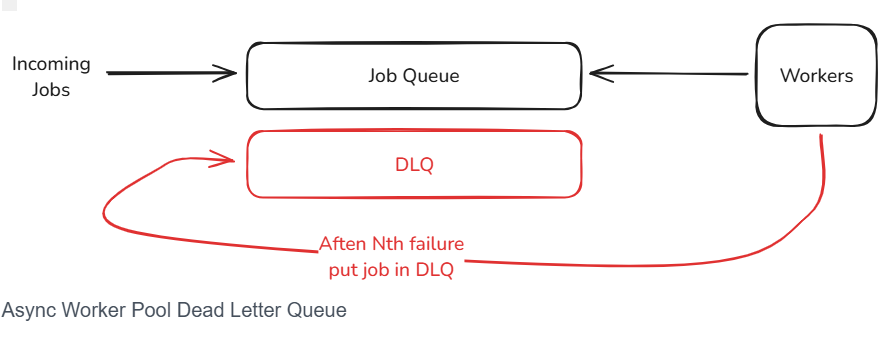

After max retries, move job to DLQ.

```
Main Queue
   ↓
Fail 1
   ↓
Fail 2
   ↓
Fail 3
   ↓
DLQ
```

### Benefits

- Protects worker pool
- Isolates bad jobs
- Allows human investigation
- Allows replay after bug fix

### Common retry policy

```
Max attempts: 3 to 5
Backoff: exponential
After max retry: DLQ
```

### Interview answer

> I would use retries with exponential backoff. If the job fails after 3–5 attempts, I move it to a Dead Letter Queue for investigation and possible reprocessing.

[figure not shown]

[figure not shown]

> Back to Index

## 16. Deep Dive 3: Preventing Duplicate Work

### Problem

User clicks multiple times.

```
Generate Report
Generate Report
Generate Report
```

This may create duplicate jobs.

Bad outcomes:

- Same report generated multiple times
- Multiple emails sent
- Duplicate charges
- Wasted compute

### Solution: Idempotency Key

Create a unique key for the operation.

Example:

```
user_id + action + date
```

For report generation:

```
user_123:annual_report:2026
```

### Flow

```
Request comes in
    ↓
Check idempotency key
    ↓
If exists: return existing job_id
    ↓
If not exists: create new job
```

### Pseudocode

```
def submit_job(user_id, job_type, idempotency_key):
    existing_job = db.get_job_by_idempotency_key(idempotency_key)

    if existing_job:
        return existing_job.job_id

    job = db.create_job(
        user_id=user_id,
        job_type=job_type,
        status="pending",
        idempotency_key=idempotency_key
    )

    queue.push({"job_id": job.job_id})

    return job.job_id
```

### Also make worker idempotent

Before performing side effects, check if already done.

Examples:

```
Was email already sent?
Was payment already charged?
Was file already created?
```

Back to Index

## 17. Deep Dive 4: Queue Backpressure

### Problem

Traffic spikes.

```
Normal traffic: 1,000 jobs/hour
Black Friday: 100,000 jobs/hour
```

Workers cannot keep up.

Queue grows:

```
10K pending
100K pending
1M pending
```

### Consequences

- Long wait times
- Queue memory/disk pressure
- Delayed jobs
- User frustration
- System overload

### Solution 1: Queue Limits

Set maximum queue depth.

```
If queue too deep:
    return "system busy"
```

Example response:

```
{
  "error": "System busy. Please retry later."
}
```

### Solution 2: Auto Scale Workers

Scale workers based on queue depth.

```
Queue depth ↑
    ↓
Add more workers
```

Important:

```
Scale on queue depth, not CPU
```

CPU may be low while queue is already growing.

### Solution 3: Rate Limit Producers

Throttle job creation.

```
User / tenant / API key rate limits
```

### Interview answer

> I would monitor queue depth and processing latency. If depth crosses a threshold, I autoscale workers. If the queue still grows, I apply backpressure by rejecting or rate-limiting new jobs.

Back to Index

## 18. Deep Dive 5: Mixed Workloads

### Problem

Small and large jobs in the same queue.

```
Small report = 5 seconds
Year-end report = 5 hours
```

Issue:

```
Short jobs wait behind long jobs
```

This is called head-of-line blocking.

### Solution: Separate Queues

```
Fast Queue
    ↓
Small jobs

Slow Queue
    ↓
Large jobs
```

### Example

```
fast_queue:
  max_duration: 60s
  workers: 50
  instance_type: small

slow_queue:
  max_duration: 6h
  workers: 10
  instance_type: compute_optimized
```

### Benefits

- Short jobs stay fast
- Long jobs do not block small jobs
- Tune workers independently
- Better autoscaling

### Alternative

Break large jobs into smaller chunks.

Example:

```
Process 10M rows
    ↓
Split into 100 chunks
    ↓
Workers process chunks in parallel
```

Back to Index

## 19. Deep Dive 6: Job Dependencies

### Problem

Some jobs require multiple steps.

Example:

```
Fetch Data
    ↓
Generate PDF
    ↓
Send Email
```

### Simple Solution

Each worker queues the next job.

```
Step 1 completes
    ↓
Queue Step 2
    ↓
Step 2 completes
    ↓
Queue Step 3
```

Example job message:

```
{
  "workflow_id": "report_123",
  "step": "generate_pdf",
  "previous_steps": ["fetch_data"],
  "context": {
    "user_id": 456,
    "data_s3_url": "s3://bucket/data.json"
  }
}
```

### Problem with manual chaining

- Hard to debug
- Retry logic spreads everywhere
- Compensation becomes difficult
- Branching becomes complex
- Monitoring is poor

### Complex Solution: Workflow Engine

Use:

| Tool | Best For |
| --- | --- |
| Temporal | Durable business workflows |
| AWS Step Functions | AWS-native orchestration |
| Airflow | Scheduled ETL workflows |

### Rule

```
Simple one-step async job
    ↓
Queue + Worker

Complex multi-step process
    ↓
Workflow Engine
```

Back to Index

## 20. Decision Tree

```
Is the task fast (< 1 sec)?
    ↓ Yes
Use synchronous API

Is the task slow (> few seconds)?
    ↓ Yes
Use Queue + Worker Pool

Can the task fail and need retry?
    ↓ Yes
Use Queue + Retry + DLQ

Can users submit duplicates?
    ↓ Yes
Use Idempotency Key

Can traffic spike?
    ↓ Yes
Use Backpressure + Autoscaling

Are there short and long jobs?
    ↓ Yes
Use Separate Queues

Are there many dependent steps?
    ↓ Yes
Use Workflow Engine
```

### Short version

```
Slow single task
    → Queue + Workers

Slow multi-step task
    → Workflow Engine

Fast simple request
    → Synchronous API
```

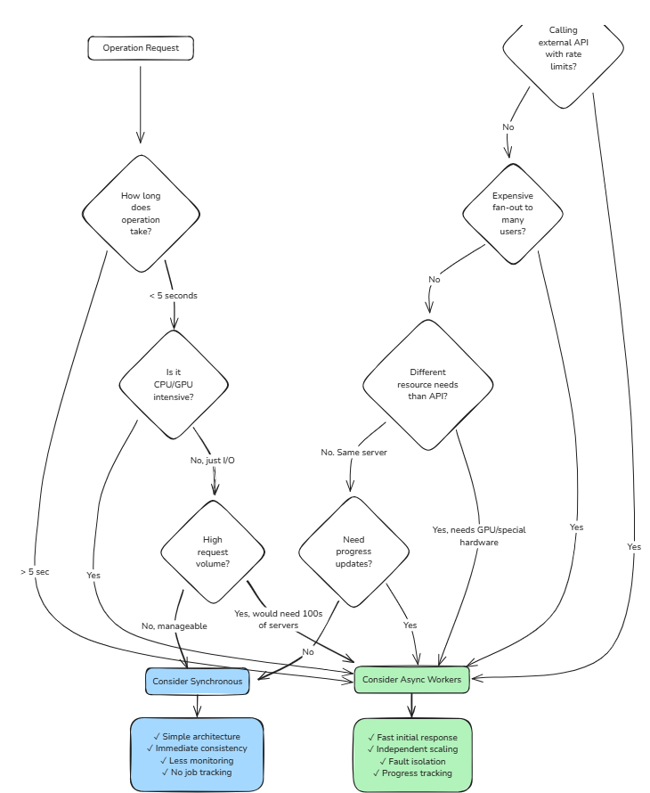

Back to Index

## 21. Golden Interview Answer

> If an operation takes more than a few seconds, I would not process it synchronously in the API request. I would create a job record, push the job ID to a durable queue, and return the job ID immediately. A separate worker pool would process jobs asynchronously and update job status in the database. I would handle failures using retries, heartbeats or visibility timeouts, and a Dead Letter Queue. I would prevent duplicate work with idempotency keys, scale workers based on queue depth, use separate queues for fast and slow jobs, and use Temporal or Step Functions when the job becomes a complex multi-step workflow.

### One-line memory hook

```
Accept fast, process async, track status, retry safely, notify when done.
```

Back to Index